# Traffic accident in Korean expressways

by Hyewon Kim, Jimin Ju, Jiweon Kim, and Nasimullah Latifi

2020. 7. 31

### This report analyzes **the Traffic accidents in 7 expressways** which occurred **from 2015 to 2019** in the region of **Gwangju and Jeonnam** province.

## Traffic accidents patterns by year

The total number of accident in expressways from 2015 to 2019 is 810, and it is decreasing every year.

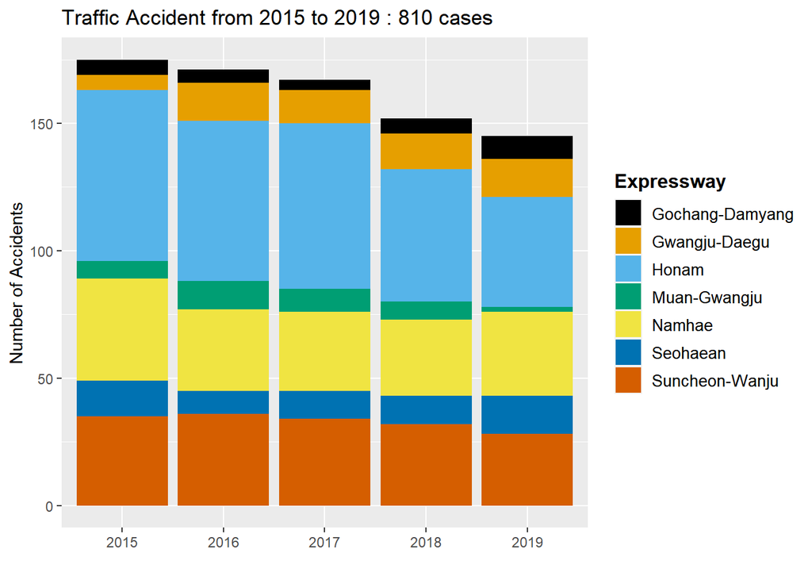

| Expressway | # of Accidents |
| --- | --- |
| Gochang-Damyang | 30 |
| Gwangju-Daegu | 63 |
| Honam | 290 |
| Muan-Gwangju | 36 |
| Namhae | 166 |
| Seohaean | 60 |
| Suncheon-Wanju | 165 |

## Traffic accident reasons per expressway

In most expressways, ‘distraction’ and ‘speeding’ were the most causes of accidents. However, in Muan-Gwangju expressway, accidents by short sight safety distance was uniquely high. Also Seohaean expressway shows the relatively high rate of accidents by road related problems.

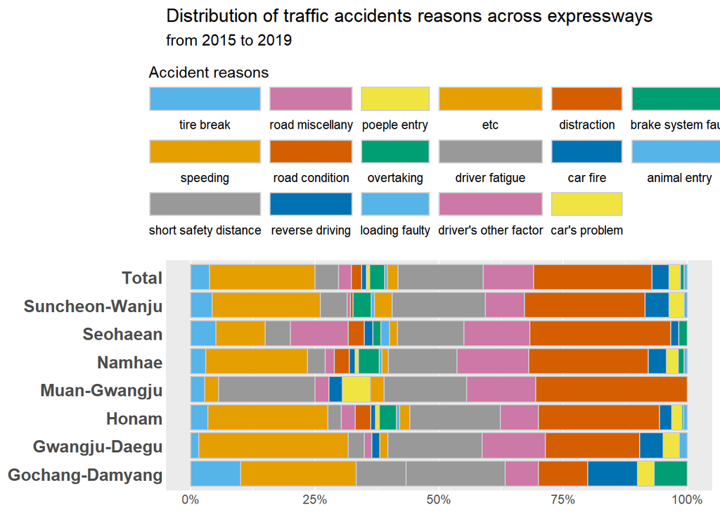

## Accidents by weather

We compared the total cases by weather in each highway. In general, people usually think that there are many accidents on rainy and cloudy days, but the result shows that most of accidents happened on sunny days.

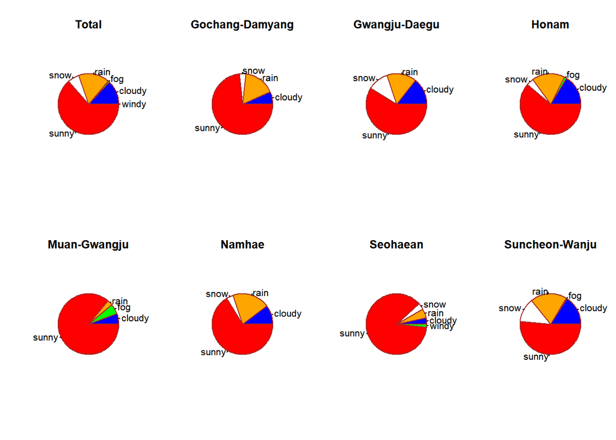

Red color means Sunny day, and sunny day took the widest part of the pie chart that meant that there were the most accidents on sunny day. Especially “Muan-Gwangju” and “Seohaean” expressways occur traffic accident the most on sunny days.

## Accidents by weekdays

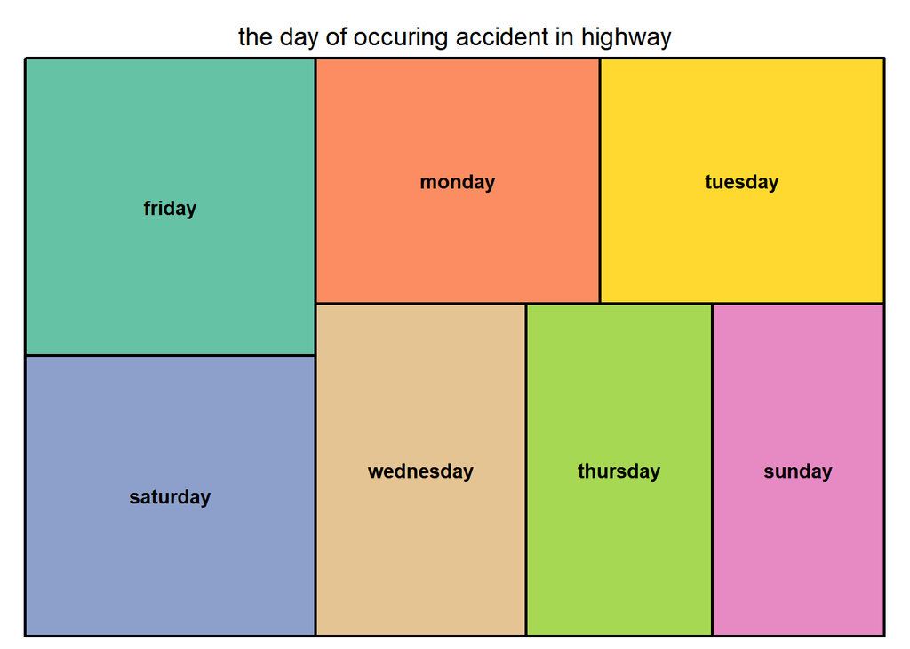

## Accidents by age groups

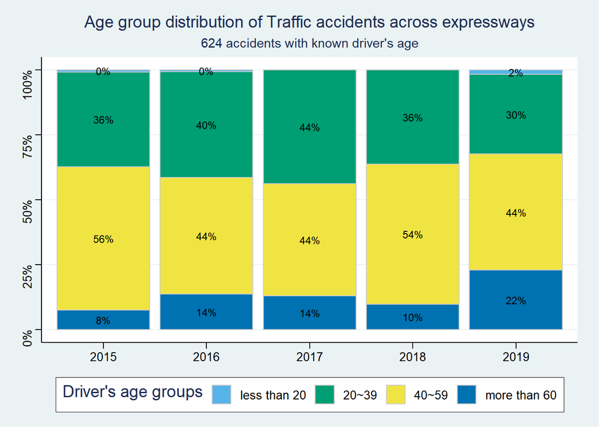

## Grouping data for gender

**1. Day/Night**

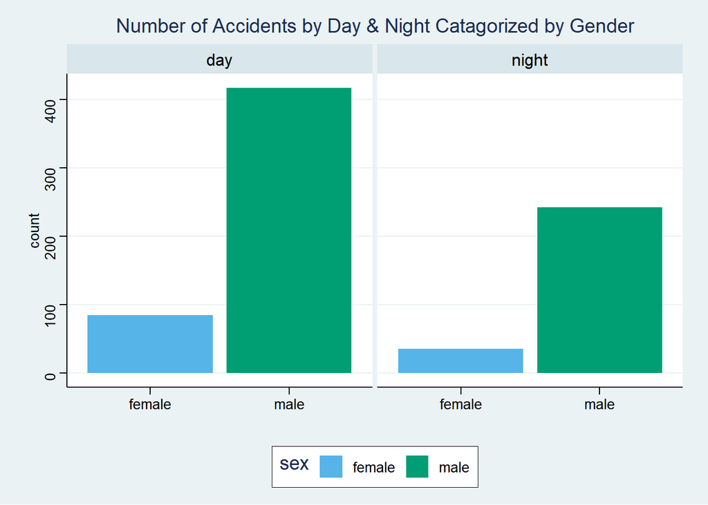

**2. Gender effects on individual expressways**

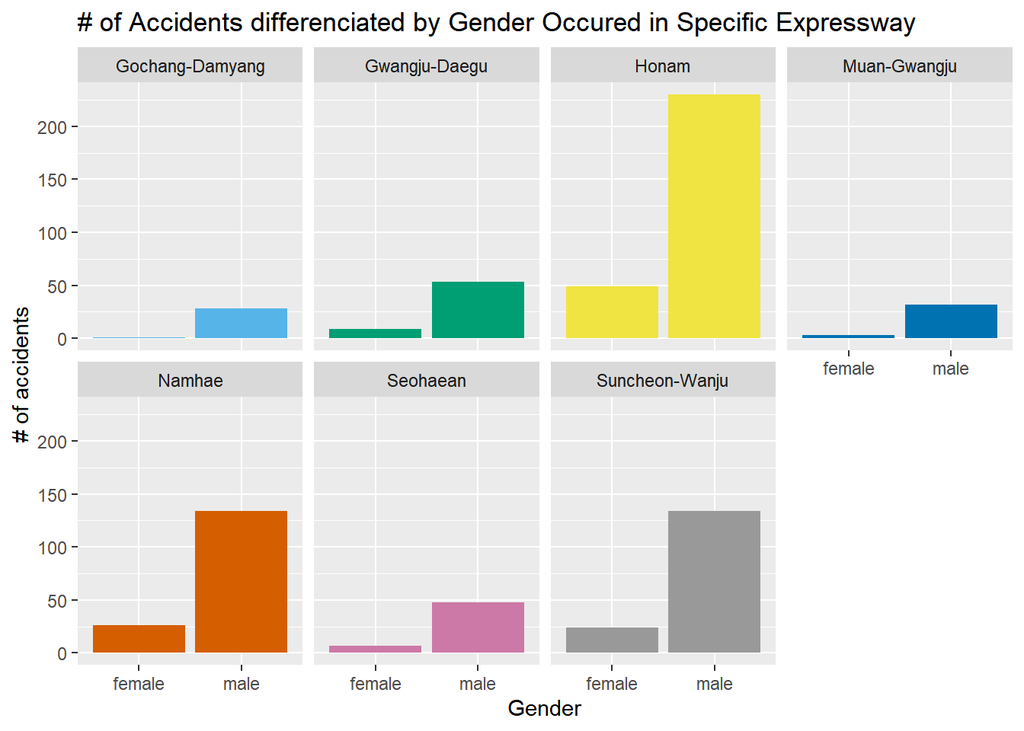

Below bar shows the relationship between the weather and gender. For example high number of accident cases are seen in a sunny weather where number of male accident is quite higher than the female.

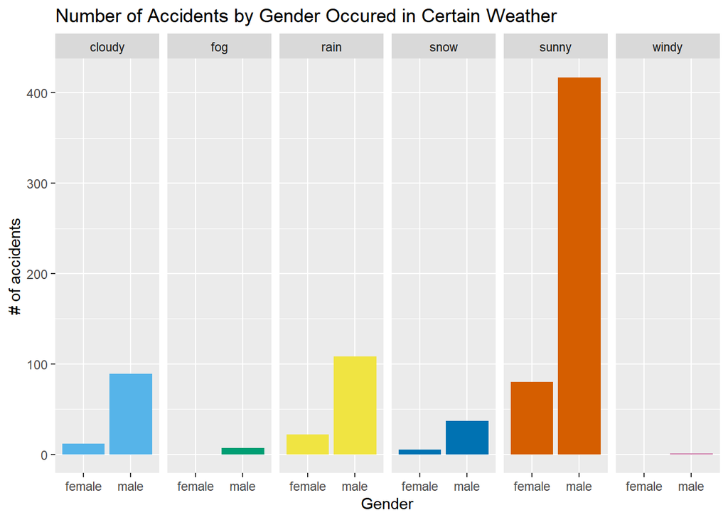

**3. Multiple comparison**

Below bar shows the relationship between the gender, expressway and weather. It shows that how many accident occured in a expressway while the weather was sunny/cloudy … in addition it show the proportion of male and female.

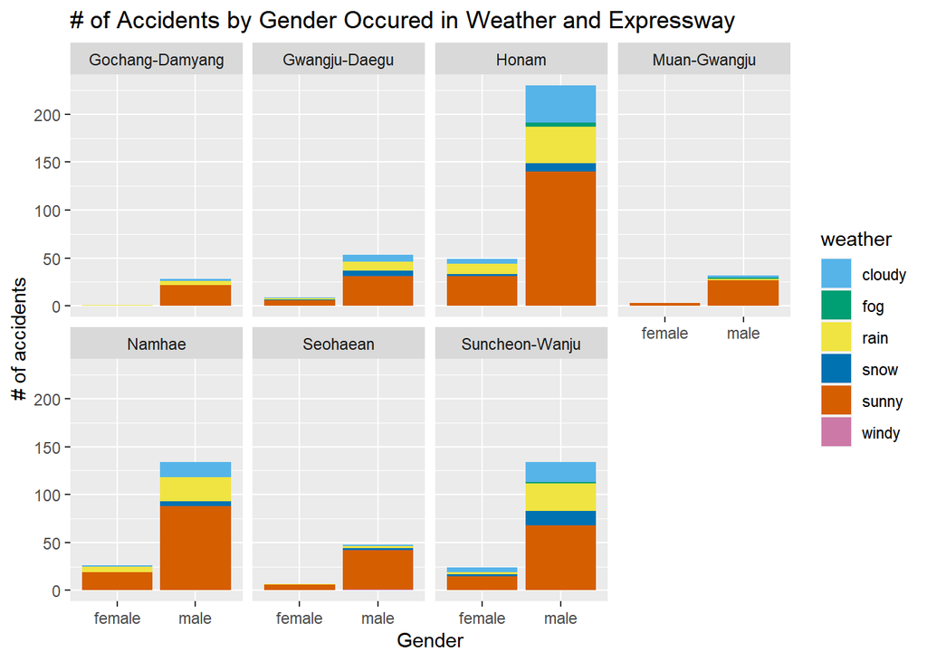

#### If you are interested, visit our dashboard: https://ids2020jimin.shinyapps.io/ids2020/